# Democracia e igualdad de género en el mundo

## Objetivos

**Objetivo principal:** describir la evolución de la democracia y de la igualdad de género en el mundo y estudiar su relación.

**Objetivos específicos:**

1. Ver cómo ha cambiado el número de democracias y autocracias desde 1800.
2. Ver cómo ha crecido el % de mujeres en los parlamentos por región desde 1945 (WWII).
3. Comprobar si los países más democráticos son también los más igualitarios.

## Datos

- Fuente: **Gapminder**, 44.609 observaciones país-año de 214 países (1800-2022).
- **Democracia:** índice Polity5, de -10 (autocracia) a +10 (democracia).
- **Igualdad de género:** índice de International IDEA (0-100) y % de escaños parlamentarios ocupados por mujeres.
- Año de referencia: **2018**, el último con datos de Polity5.

## 1. Olas de democratización

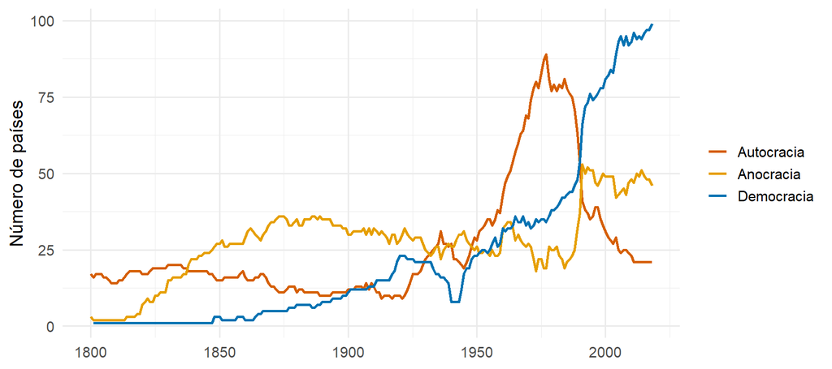

De 23 democracias en 1922 a 8 en 1942, y a **99 en 2018**.

## 2. Mujeres en los parlamentos

La mediana de los países pasa del **4,8 %** en 1975 al **23,4 %** en 2021.

Indicadores por región en 2018

| Región | Países | % democracias | Igualdad IDEA (mediana) | % parlamentarias (mediana) |
| --- | --- | --- | --- | --- |
| África | 55 | 38,5 | 51,6 | 19,2 |
| América | 37 | 80,8 | 60,3 | 27,3 |
| Asia | 63 | 45,7 | 47,4 | 15,3 |
| Europa | 51 | 88,1 | 74,9 | 27,1 |

## 2. Igualdad de género por región (2018)

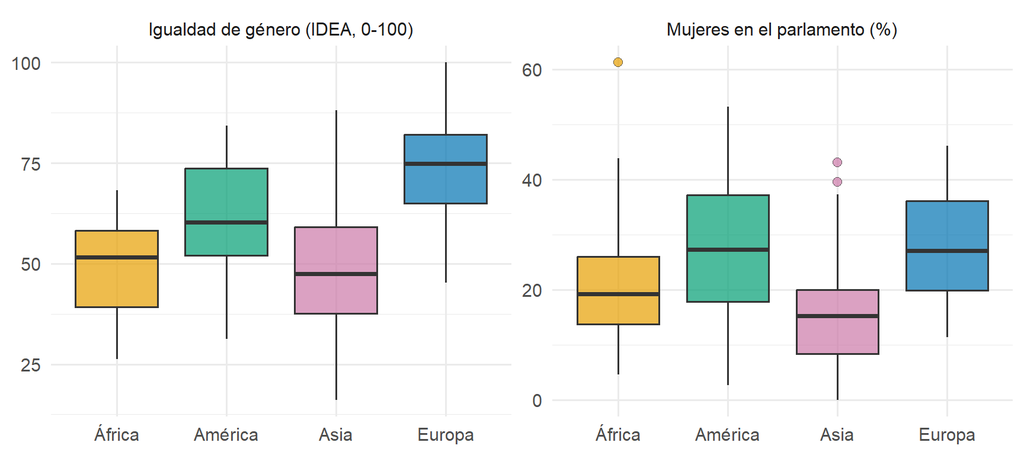

Atípicos: **Ruanda** (61 % de parlamentarias) y **Emiratos Árabes Unidos** (43 %), sin ser democracias.

## 3. Democracia e igualdad de género

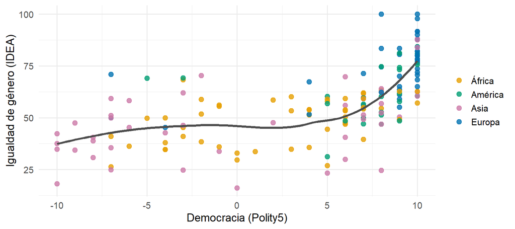

Correlación con la igualdad de IDEA: **ρ = 0,71**. Con el % de parlamentarias, mucho más débil: ρ = 0,28.

## Conclusiones

- La democracia se ha extendido **por olas**, con retrocesos en el periodo de entreguerras y un gran avance desde 1989.
- La presencia de mujeres en los parlamentos ha **aumentado en todas las regiones**, sobre todo desde el año 2000.
- Democracia e igualdad de género **están relacionadas, pero no siempre van juntas**: la representación parlamentaria femenina depende poco del régimen.
- Son correlaciones, no relaciones causales.